# Project 1

Angela Zhao

# **Introduction**

The **Project1_coffee.csv** dataset shows data for different coffee producers and contains the following variables:

- *Country*
- *RegionDetail*: Where the coffee beans were grown
- *Altitude*: Altitude of the farm the coffee beans were grown on
- *Year*: Production Year
- *ProcessingMethod*: How the coffee beans were processed
- *BeanColor*
- *BagsProduced*: How many bags of coffee were produced
- *Rating*: Professional rating (from 0-100) of different coffee producers

Sources: [Coffee Quality Database](https://github.com/jldbc/coffee-quality-database), retrieved from [here](https://corgis-edu.github.io/corgis/csv/coffee/).

My chosen outcome is *BagsProduced*. The predictors I will be investigating are *Year*, *Rating*, and *Altitude*.

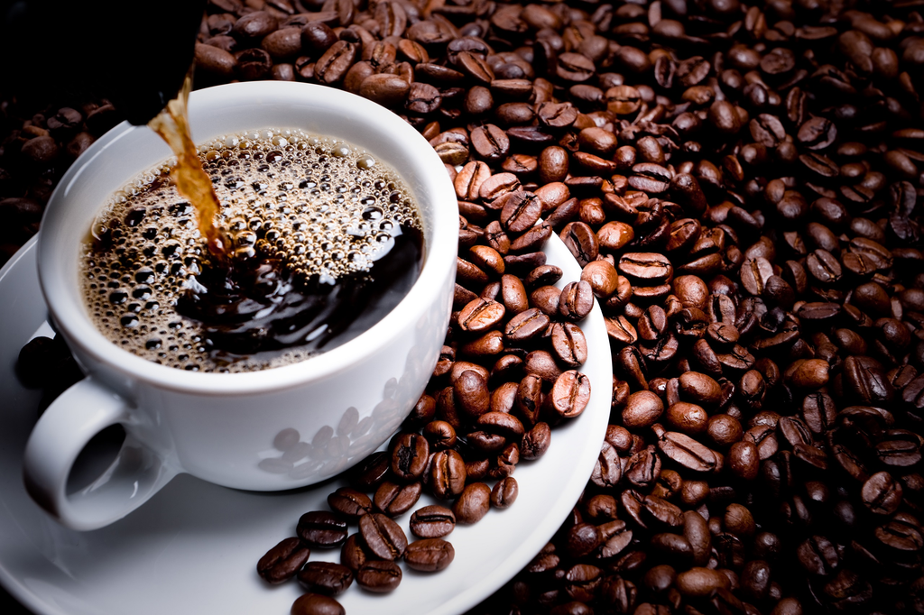

Source: “Paramount Coffee - Roasting the Finest Coffee: Paramount Coffee.” Paramount Coffee - Roasting the Finest Coffee | Paramount Coffee, paramountcoffee.com/?SID=d48dc2581bd5cf8482e280c1ba4724ee. Accessed 19 Sept. 2023.

# **Outcome Variable Distribution**

### Bags Produced

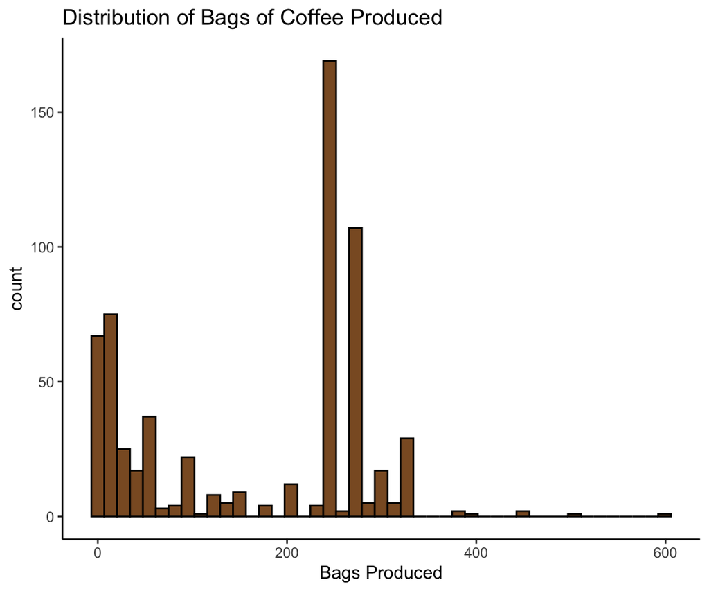

*This graph shows the distribution of bags of coffee produced.*  
The five number summary is 1, 29, 250, 275, 600 (min,Q1,med,Q2,max). The average number of bags produced is 168.67 bags. Half of the coffee produced was between 29 and 275 bags.

# **Bivariate Relationships**

### Year

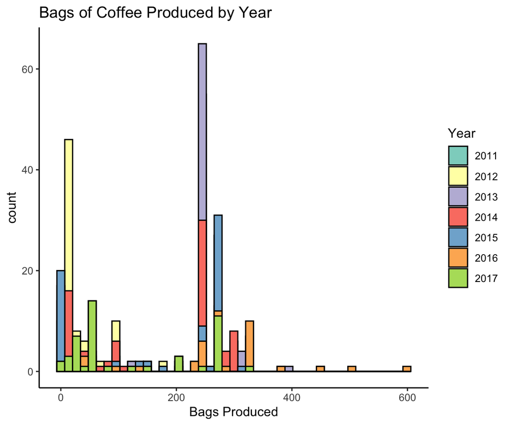

| Year | Bags Produced Median |
| --- | --- |
| 2011 | 75 |
| 2012 | 100 |
| 2013 | 250 |
| 2014 | 250 |
| 2015 | 250 |
| 2016 | 275 |
| 2017 | 50 |

### Rating

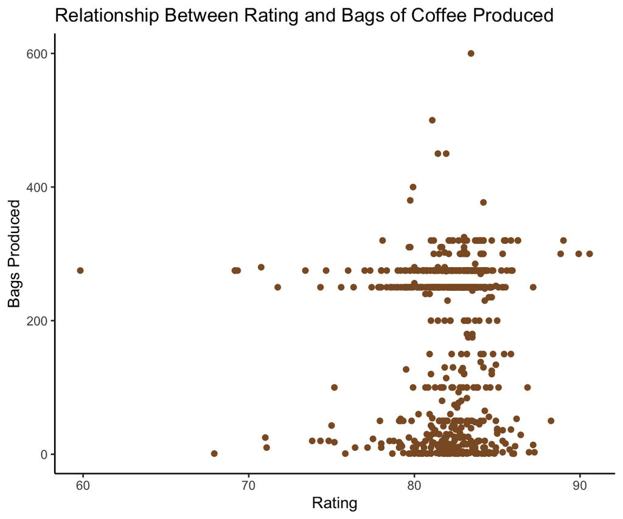

*This graph shows the relationship between the rating of a coffee producer and the number of bags produced.*  
There is a correlation of 0.03 between rating and number of bags of coffee produced. This indicates that there is very little correlation between the two variables. There might be a slight positive relationship where the number of bags produced increases when the rating is higher, but it is not a strong enough correlation to be considered significant.

### Altitude

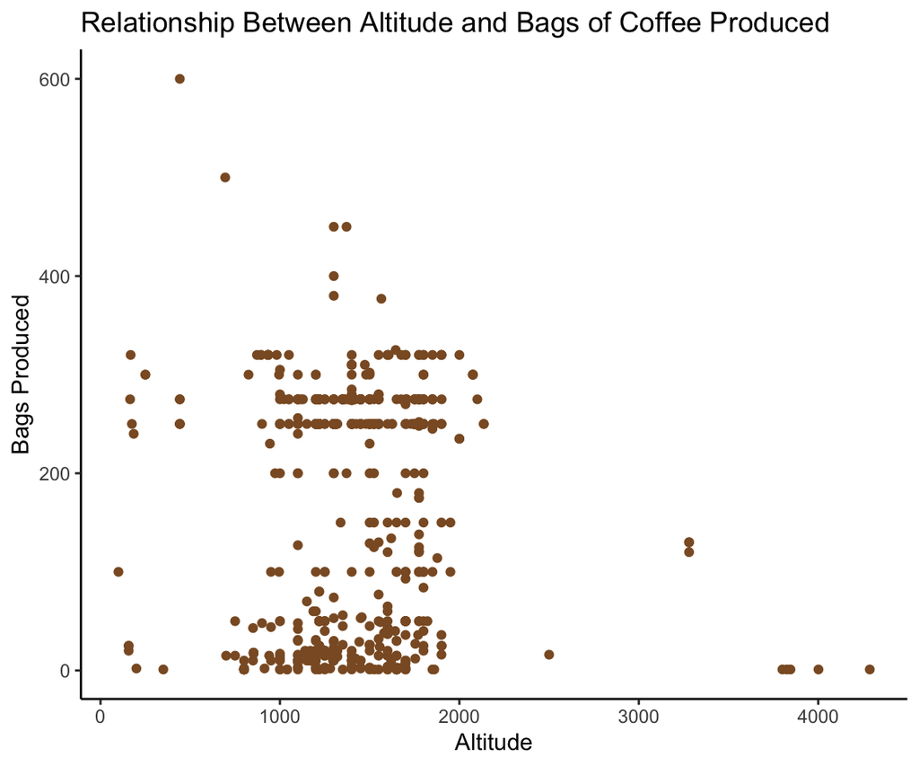

*This graph shows the relationship between the altitude a coffee bean was grown at and the number of bags produced.*  
There is a correlation of 0 between altitude and number of bags of coffee produced. This indicates that there is no correlation between the two variables. However, looking solely at the graph, it looks like the points at the higher altitudes have less bags produced, and the coffee with the most bags produced are at lower altitudes.

# **Conclusion**

> References: https://github.com/jldbc/coffee-quality-database, https://corgis-edu.github.io/corgis/csv/coffee/